# Project MOBIL

First, we load all necessary packages

```r
library(readr)
library(data.table)
library(summarytools)
library(hdm)
library(glmnet)
library(DoubleML)
library(mlr3)
library(ranger)
library(ggplot2)
library(ggpubr)
```

# 1. Data cleaning process

We import GDIM 2023 database for the official website

```r
url = "https://datacatalogfiles.worldbank.org/ddh-published/0050771/DR0065670/GDIM_2023_03.csv"
data_raw = read.csv(url)
head(data_raw)
```

|  | country | code | region | region_noHICgroup | incgroup2 | incgroup3 | incgroup4 | fragile | survey | year | status | cohort | parent | child | obs | P1 | P2 | P3 | P4 | P5 | C1 | C2 | C3 | C4 | C5 | MEANp | MEANc | SDp | SDc | … |
| --- | --- | --- | --- | --- | --- | --- | --- | --- | --- | --- | --- | --- | --- | --- | --- | --- | --- | --- | --- | --- | --- | --- | --- | --- | --- | --- | --- | --- | --- | --- |
| 1 | Afghanistan | AFG | South Asia | South Asia | Developing economies | Low income | Low income | Yes | NRVA | 2011 | Co-residents only | 1980 | avg | all | 3956 | 0.6661248 | 0.09858292 | 0.17093068 | 0.04303147 | 0.02133018 | 0.5118570 | 0.02580462 | 0.1641913 | 0.1834691 | 0.1146780 | 2.480162 | 5.582401 | 3.809782 | 5.857765 | … |
| 2 | Afghanistan | AFG | South Asia | South Asia | Developing economies | Low income | Low income | Yes | NRVA | 2011 | Co-residents only | 1980 | avg | daughter | 721 | 0.6153211 | 0.09927175 | 0.21277559 | 0.05196906 | 0.02066248 | 0.6284814 | 0.02337842 | 0.0992651 | 0.1323224 | 0.1165526 | 2.989992 | 4.331731 | 4.010379 | 5.902685 | … |
| 3 | Afghanistan | AFG | South Asia | South Asia | Developing economies | Low income | Low income | Yes | NRVA | 2011 | Co-residents only | 1980 | avg | son | 3235 | 0.6786987 | 0.09841243 | 0.16057406 | 0.04081942 | 0.02149544 | 0.4829925 | 0.02640510 | 0.1802605 | 0.1961279 | 0.1142140 | 2.353979 | 5.891941 | 3.748495 | 5.806141 | … |
| 4 | Afghanistan | AFG | South Asia | South Asia | Developing economies | Low income | Low income | Yes | NRVA | 2011 | Co-residents only | 1980 | dad | all | 4137 | 0.6865805 | 0.04760981 | 0.05730859 | 0.15090708 | 0.05759400 | 0.5145621 | 0.02604694 | 0.1656379 | 0.1815510 | 0.1122020 | 3.756049 | 5.538275 | 5.493762 | 5.842035 | … |
| 5 | Afghanistan | AFG | South Asia | South Asia | Developing economies | Low income | Low income | Yes | NRVA | 2011 | Co-residents only | 1980 | dad | daughter | 744 | 0.6390916 | 0.05232841 | 0.05408631 | 0.19009995 | 0.06439372 | 0.6303540 | 0.02278138 | 0.1037357 | 0.1295529 | 0.1135761 | 4.520877 | 4.277768 | 5.804775 | 5.869737 | … |
| 6 | Afghanistan | AFG | South Asia | South Asia | Developing economies | Low income | Low income | Yes | NRVA | 2011 | Co-residents only | 1980 | dad | son | 3393 | 0.6981243 | 0.04646278 | 0.05809188 | 0.14137988 | 0.05594109 | 0.4864149 | 0.02684075 | 0.1806854 | 0.1941910 | 0.1118680 | 3.570130 | 5.844686 | 5.400092 | 5.794936 | … |

We create our research data from the GDIM data

```r
data_raw = data_raw[,c(1,4,5,8,12:14,26:29,31,40)] #removing unnecessary var
df = data.frame(
  mobility = data_raw$CAT,
  inequality = data_raw$SDc - data_raw$SDp,
  expansion = data_raw$MEANc - data_raw$MEANp,
  dependency = data_raw$COR, # parental dependency
  cohort = as.factor(data_raw$cohort), # generations
  fragile = as.factor(data_raw$fragile),
  developing = as.factor(ifelse(data_raw$incgroup2 == "Developing economies", "Yes", "No")),
  region = as.factor(data_raw$region_noHICgroup),
  mom = as.factor(ifelse(data_raw$parent == "mom", "Yes", "No")),
  daughter = as.factor(ifelse(data_raw$child == "daughter", "Yes", "No"))
)
```

We summarize our data set as follow:

```r
dfSummary(df,
               plain.ascii  = FALSE,
               style        = "grid",
               graph.magnif = 0.75,
               graph.col = FALSE,
               valid.col    = FALSE)
```

```
### Data Frame Summary
#### df
**Dimensions:** 6725 x 10
**Duplicates:** 36

+----+-------------+--------------------------------+----------------------+---------+
| No | Variable    | Stats / Values                 | Freqs (% of Valid)   | Missing |
+====+=============+================================+======================+=========+
| 1  | mobility\   | Mean (sd) : 0.5 (0.2)\         | 6630 distinct values | 0\      |
|    | [numeric]   | min < med < max:\              |                      | (0.0%)  |
|    |             | 0 < 0.6 < 1\                   |                      |         |
|    |             | IQR (CV) : 0.3 (0.4)           |                      |         |
+----+-------------+--------------------------------+----------------------+---------+
| 2  | inequality\ | Mean (sd) : 0.2 (1.3)\         | 6681 distinct values | 0\      |
|    | [numeric]   | min < med < max:\              |                      | (0.0%)  |
|    |             | -3.2 < 0 < 5.2\                |                      |         |
|    |             | IQR (CV) : 1.7 (6.5)           |                      |         |
+----+-------------+--------------------------------+----------------------+---------+
| 3  | expansion\  | Mean (sd) : 3.1 (1.9)\         | 6678 distinct values | 0\      |
|    | [numeric]   | min < med < max:\              |                      | (0.0%)  |
|    |             | -3.4 < 3.1 < 10.9\             |                      |         |
|    |             | IQR (CV) : 2.6 (0.6)           |                      |         |
+----+-------------+--------------------------------+----------------------+---------+
| 4  | dependency\ | Mean (sd) : 0.4 (0.1)\         | 6674 distinct values | 0\      |
|    | [numeric]   | min < med < max:\              |                      | (0.0%)  |
|    |             | -0.1 < 0.4 < 1\                |                      |         |
|    |             | IQR (CV) : 0.2 (0.3)           |                      |         |
+----+-------------+--------------------------------+----------------------+---------+
| 5  | cohort\     | 1\. 1940\                      | 1189 (17.7%)\        | 0\      |
|    | [factor]    | 2\. 1950\                      | 1259 (18.7%)\        | (0.0%)  |
|    |             | 3\. 1960\                      | 1275 (19.0%)\        |         |
|    |             | 4\. 1970\                      | 1271 (18.9%)\        |         |
|    |             | 5\. 1980                       | 1731 (25.7%)         |         |
+----+-------------+--------------------------------+----------------------+---------+
| 6  | fragile\    | 1\. No\                        | 5890 (87.6%)\        | 0\      |
|    | [factor]    | 2\. Yes                        | 835 (12.4%)          | (0.0%)  |
+----+-------------+--------------------------------+----------------------+---------+
| 7  | developing\ | 1\. No\                        | 2227 (33.1%)\        | 0\      |
|    | [factor]    | 2\. Yes                        | 4498 (66.9%)         | (0.0%)  |
+----+-------------+--------------------------------+----------------------+---------+
| 8  | region\     | 1\. East Asia & Pacific\       | 837 (12.4%)\         | 0\      |
|    | [factor]    | 2\. Europe & Central Asia\     | 2788 (41.5%)\        | (0.0%)  |
|    |             | 3\. Latin America & Caribbean\ | 687 (10.2%)\         |         |
|    |             | 4\. Middle East & North Afric\ | 468 ( 7.0%)\         |         |
|    |             | 5\. North America\             | 120 ( 1.8%)\         |         |
|    |             | 6\. South Asia\                | 332 ( 4.9%)\         |         |
|    |             | 7\. Sub-Saharan Africa         | 1493 (22.2%)         |         |
+----+-------------+--------------------------------+----------------------+---------+
| 9  | mom\        | 1\. No\                        | 5091 (75.7%)\        | 0\      |
|    | [factor]    | 2\. Yes                        | 1634 (24.3%)         | (0.0%)  |
+----+-------------+--------------------------------+----------------------+---------+
| 10 | daughter\   | 1\. No\                        | 4483 (66.7%)\        | 0\      |
|    | [factor]    | 2\. Yes                        | 2242 (33.3%)         | (0.0%)  |
+----+-------------+--------------------------------+----------------------+---------+
```

# 2. Descriptive analysis

## 2.1. Scatter plots with continuous variables

First, we create a function to apply all continuous variables:

```r
plot_scatter <- function(x_var, y_var) {
  ggscatter(df, x_var, y_var,
            color = "grey",
            add = "reg.line",
            add.params = list(color = "blue", fill = "lightgray"),
            conf.int = TRUE) +
    stat_cor(method = "pearson",label.y = 1.1) + ylim(0, 1.1)
}
```

The Figure 2 in the study was generated by this code:

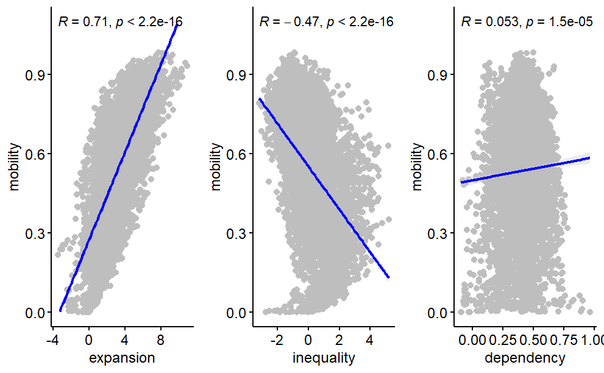

```r
Fig_2 = ggarrange(plot_scatter("expansion", "mobility"),
          plot_scatter("inequality", "mobility"),
          plot_scatter("dependency", "mobility"),
          ncol = 3, nrow = 1)
print(Fig_2)
```

## 2.2. Violin plots with categorical variables

First, we create a function to apply all categorical variables:

```r
plot_violin <- function(x_var, y_var) {
  ggviolin(df, x = x_var, y = y_var, fill = x_var,
           legend.position = "none",
           add = "boxplot", add.params = list(fill = "white")) +
    stat_compare_means(method = "anova", label.y = 1.1) + guides(fill = FALSE)
}
```

The Figure 4 in the study was generated by this code:

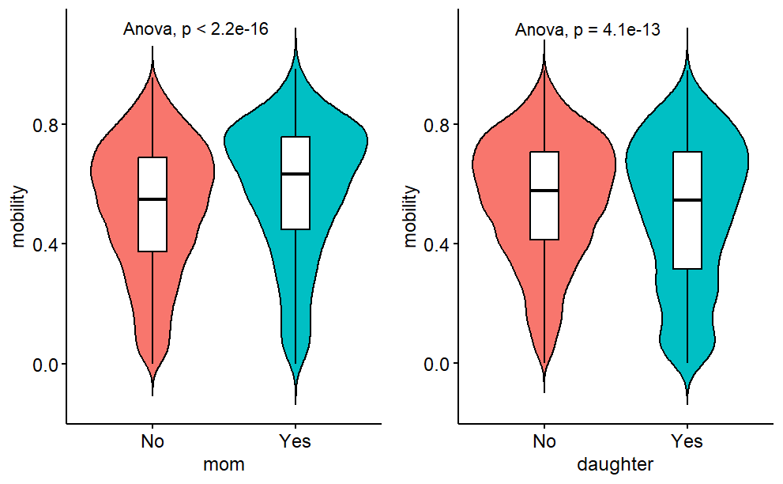

```r
Fig_4 = ggarrange(plot_violin("mom", "mobility"),
          plot_violin("daughter", "mobility"),
          ncol = 2, nrow = 1)
print(Fig_4)
```

The Figure 1 in the study was generated by this code:

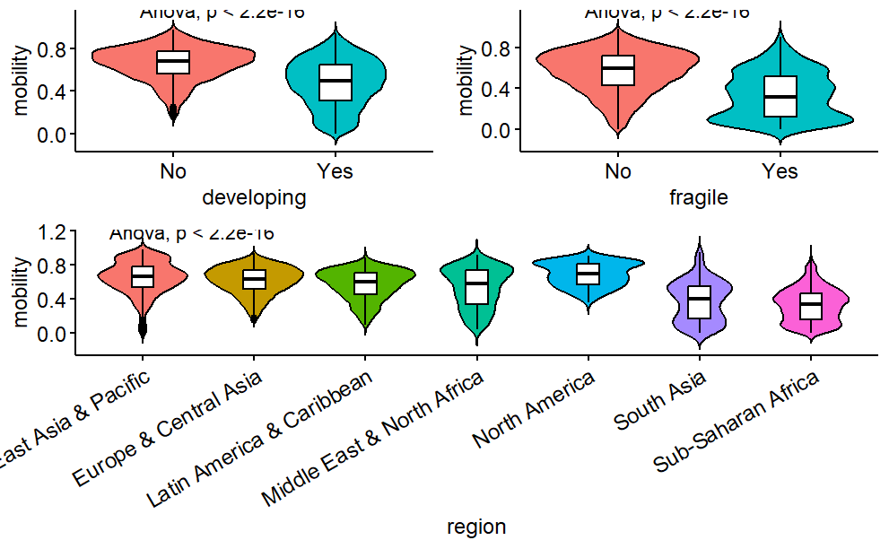

```r
Fig_1 = ggarrange(ggarrange(plot_violin("developing", "mobility"),
                    plot_violin("fragile", "mobility"),
                    ncol = 2, nrow = 1),
          plot_violin("region", "mobility") + rotate_x_text(30),
          ncol = 1, nrow = 2, heights=c(1,1.5))
print(Fig_1)
```

# 3. Data modelling

First, we convert the current research to fit well a research model:

```r
data <- df
data$mobility <- with(data_raw, CAT - ave(CAT, country)) # remove fixed effects
offset <- abs(min(data[sapply(data, is.numeric)])) + 1
data[sapply(data, is.numeric)] <- log(data[sapply(data, is.numeric)] + offset)
data <- model.matrix(~ . - 1, data = data) # convert into model data
data <- data[, -which(colnames(data) == "cohort1940")] # transform to dummy-coding
colnames(data) <- gsub("[^[:alnum:]]", "", colnames(data)) # correct var names
```

Then, we summarize the modeled data as follow:

```r
dfSummary(data,
               plain.ascii  = FALSE,
               style        = "grid",
               graph.magnif = 0.75,
               graph.col = FALSE,
               valid.col    = FALSE)
```

```
data was converted to a data frame
```

```
### Data Frame Summary
#### data
**Dimensions:** 6725 x 18
**Duplicates:** 36

+----+------------------------------+------------------------+----------------------+---------+
| No | Variable                     | Stats / Values         | Freqs (% of Valid)   | Missing |
+====+==============================+========================+======================+=========+
| 1  | mobility\                    | Mean (sd) : 1.5 (0)\   | 6633 distinct values | 0\      |
|    | [numeric]                    | min < med < max:\      |                      | (0.0%)  |
|    |                              | 1.4 < 1.5 < 1.6\       |                      |         |
|    |                              | IQR (CV) : 0 (0)       |                      |         |
+----+------------------------------+------------------------+----------------------+---------+
| 2  | inequality\                  | Mean (sd) : 1.5 (0.3)\ | 6681 distinct values | 0\      |
|    | [numeric]                    | min < med < max:\      |                      | (0.0%)  |
|    |                              | 0.2 < 1.5 < 2.3\       |                      |         |
|    |                              | IQR (CV) : 0.4 (0.2)   |                      |         |
+----+------------------------------+------------------------+----------------------+---------+
| 3  | expansion\                   | Mean (sd) : 2 (0.3)\   | 6678 distinct values | 0\      |
|    | [numeric]                    | min < med < max:\      |                      | (0.0%)  |
|    |                              | 0 < 2 < 2.7\           |                      |         |
|    |                              | IQR (CV) : 0.3 (0.1)   |                      |         |
+----+------------------------------+------------------------+----------------------+---------+
| 4  | dependency\                  | Mean (sd) : 1.6 (0)\   | 6674 distinct values | 0\      |
|    | [numeric]                    | min < med < max:\      |                      | (0.0%)  |
|    |                              | 1.5 < 1.6 < 1.7\       |                      |         |
|    |                              | IQR (CV) : 0 (0)       |                      |         |
+----+------------------------------+------------------------+----------------------+---------+
| 5  | cohort1950\                  | Min  : 0\              | 0 : 5466 (81.3%)\    | 0\      |
|    | [numeric]                    | Mean : 0.2\            | 1 : 1259 (18.7%)     | (0.0%)  |
|    |                              | Max  : 1               |                      |         |
+----+------------------------------+------------------------+----------------------+---------+
| 6  | cohort1960\                  | Min  : 0\              | 0 : 5450 (81.0%)\    | 0\      |
|    | [numeric]                    | Mean : 0.2\            | 1 : 1275 (19.0%)     | (0.0%)  |
|    |                              | Max  : 1               |                      |         |
+----+------------------------------+------------------------+----------------------+---------+
| 7  | cohort1970\                  | Min  : 0\              | 0 : 5454 (81.1%)\    | 0\      |
|    | [numeric]                    | Mean : 0.2\            | 1 : 1271 (18.9%)     | (0.0%)  |
|    |                              | Max  : 1               |                      |         |
+----+------------------------------+------------------------+----------------------+---------+
```

[output cut: 29 more lines]

```
|    | [numeric]                    | Mean : 0\              | 1 :  332 ( 4.9%)     | (0.0%)  |
|    |                              | Max  : 1               |                      |         |
+----+------------------------------+------------------------+----------------------+---------+
| 16 | regionSubSaharanAfrica\      | Min  : 0\              | 0 : 5232 (77.8%)\    | 0\      |
|    | [numeric]                    | Mean : 0.2\            | 1 : 1493 (22.2%)     | (0.0%)  |
|    |                              | Max  : 1               |                      |         |
+----+------------------------------+------------------------+----------------------+---------+
| 17 | momYes\                      | Min  : 0\              | 0 : 5091 (75.7%)\    | 0\      |
|    | [numeric]                    | Mean : 0.2\            | 1 : 1634 (24.3%)     | (0.0%)  |
|    |                              | Max  : 1               |                      |         |
+----+------------------------------+------------------------+----------------------+---------+
| 18 | daughterYes\                 | Min  : 0\              | 0 : 4483 (66.7%)\    | 0\      |
|    | [numeric]                    | Mean : 0.3\            | 1 : 2242 (33.3%)     | (0.0%)  |
|    |                              | Max  : 1               |                      |         |
+----+------------------------------+------------------------+----------------------+---------+
```

## 3.1. For the research question Q1

In this section, we attempt to estimate **the direct and indirect effects** of the target variables (education inequality, education expansion, and parental dependence).

### 3.1.1. Rigorous Lasso without interaction

This model addresses multicollinearity among explanatory variables, so produce a **pure** effects. In this study, it measures **the direct effects** of the target variables. First, we create a function for this kind of model:

```r
partiall_out <- function(dt,y, dvar) {
  x <- as.matrix(data)[,-c(which(colnames(dt) == y), which(colnames(dt) == dvar))]
  y <- data[, y]
  d <- data[, dvar]
  effect <- rlassoEffect(x, y, d)
  result <- summary(effect)
  result_df <- as.data.frame(result$coefficients)
  rownames(result_df)[rownames(result_df) == "d1"] = dvar
  return(result_df)
}
```

Then, we run this model to answer the question Q1:

```r
Q1_dl = rbind(partiall_out(data,"mobility","inequality"),
              partiall_out(data,"mobility","expansion"),
              partiall_out(data,"mobility","dependency")
)
print(Q1_dl)
```

|  | Estimate. | Std. Error | t value | Pr(>\|t\|) |
| --- | --- | --- | --- | --- |
| inequality | -0.01140383 | 0.001053242 | -10.82736 | 2.554028e-27 |
| expansion | 0.05999761 | 0.001447368 | 41.45290 | 0.000000e+00 |
| dependency | -0.12597851 | 0.011041668 | -11.40937 | 3.754243e-30 |

### 3.1.2. Double machine learning - PLR model

This model addresses confounding problems, therefore, it produces the **total impacts** (include direct and indirect effects).

First, we create a function for this kind of model:

```r
fit_dml_plr <- function(dt, y, d) {
  dt = as.data.table(dt)
  dml_data <- DoubleMLData$new(dt, y_col = y, d_cols = d,
                               x_cols = colnames(dt)[!(colnames(dt) %in% c(y,d))])
  set.seed(123) # required to replicate sample split
  learner_l <- lrn("regr.ranger", num.trees = 500, min.node.size = 2, max.depth = 5)
  learner_m <- lrn("regr.ranger", num.trees = 500, min.node.size = 2, max.depth = 5)
  dml_plr <- DoubleMLPLR$new(dml_data,
                             ml_l = learner_l,
                             ml_m = learner_m)
  dml_plr$fit()
  result <- dml_plr$summary()
  return(result)
}
```

Then, we run this model to answer the question Q1:

```r
Q1_plr = rbind(fit_dml_plr(data,"mobility","inequality"),
               fit_dml_plr(data,"mobility","expansion"),
               fit_dml_plr(data,"mobility","dependency"))
```

[output not shown]

```r
print(Q1_plr)
```

```
              Estimate.  Std. Error   t value     Pr(>|t|)
inequality -0.009091374 0.001171507 -7.760411 8.465479e-15
expansion   0.054435573 0.001390941 39.135781 0.000000e+00
dependency -0.098267981 0.011440103 -8.589781 8.713488e-18
```

## 3.2. For the research question Q2

In this section, we attempt to estimate the multidimensional effects of gender on the intergenerational mobility by the Rigorous Lasso with interaction (each interaction serves a dimension), and finally to confirm the overall effect of gender on the mobility by Double machine learning - IRM model.

### 3.2.1. Rigorous Lasso with interaction

This model addresses multicollinearity among variables, so it produces **the pure effects**. To account for the multidimensional effects, we add interaction terms in to this model.

First, we create a function for this kind of model:

```r
rlasso_effects <- function(dt, y, x) {
  dt = as.data.frame(dt)
  # Get all column names except x and y
  all_cols <- setdiff(names(dt), c(x, y))
  # Model matrix
  x_names <- paste(all_cols, collapse = "+")
  formula <- as.formula(paste0("~ -1 + ", x, "+", x, ":(", x_names, ")+(", x_names, ")^2"))
  X <- model.matrix(formula, data = dt)
  X <- X[, which(apply(X, 2, var) != 0)] #exclude constant variables
  index_x <- grep(x, colnames(X))
  effects <- rlassoEffects(x = X, y = dt[, y], index = index_x)
  result <- summary(effects)
  result_df <- as.data.frame(result$coefficients)
  return(result_df)
}
```

Then, we run this model to answer the question Q2:

```r
Q2_mom_dl = rlasso_effects(data,"mobility","momYes")
Q2_dau_dl = rlasso_effects(data,"mobility","daughterYes")
print(Q2_mom_dl)
```

|  | Estimate. | Std. Error | t value | Pr(>\|t\|) |
| --- | --- | --- | --- | --- |
| momYes | -0.0878147004 | 0.030320470 | -2.89621835 | 0.0037768950 |
| momYes:inequality | 0.0048277815 | 0.001984897 | 2.43225774 | 0.0150050256 |
| momYes:expansion | 0.0057241192 | 0.002053814 | 2.78706769 | 0.0053187368 |
| momYes:dependency | 0.0473280598 | 0.019496014 | 2.42757620 | 0.0152000935 |
| momYes:cohort1950 | 0.0001890374 | 0.001643214 | 0.11504120 | 0.9084124680 |
| momYes:cohort1960 | -0.0007093963 | 0.001639589 | -0.43266709 | 0.6652566421 |
| momYes:cohort1970 | -0.0007660412 | 0.001638096 | -0.46764123 | 0.6400411778 |
| momYes:cohort1980 | -0.0006247323 | 0.001537323 | -0.40637680 | 0.6844657606 |
| momYes:fragileYes | -0.0030096808 | 0.001654692 | -1.81887668 | 0.0689302463 |
| momYes:developingYes | -0.0017583852 | 0.001255667 | -1.40035919 | 0.1614057845 |

[output cut: 7 more lines]

```r
print(Q2_dau_dl)
```

|  | Estimate. | Std. Error | t value | Pr(>\|t\|) |
| --- | --- | --- | --- | --- |
| daughterYes | 0.0529185043 | 0.027406786 | 1.9308541 | 5.350110e-02 |
| daughterYes:inequality | -0.0148024500 | 0.001877199 | -7.8853905 | 3.135535e-15 |
| daughterYes:expansion | -0.0008280056 | 0.001871463 | -0.4424377 | 6.581725e-01 |
| daughterYes:dependency | -0.0270095689 | 0.017364209 | -1.5554736 | 1.198333e-01 |
| daughterYes:cohort1950 | 0.0025497129 | 0.001484693 | 1.7173333 | 8.591828e-02 |
| daughterYes:cohort1960 | 0.0071222280 | 0.001481981 | 4.8058843 | 1.540690e-06 |
| daughterYes:cohort1970 | 0.0105167111 | 0.001476182 | 7.1242648 | 1.046377e-12 |
| daughterYes:cohort1980 | 0.0190005834 | 0.001389616 | 13.6732577 | 1.466787e-42 |
| daughterYes:fragileYes | -0.0027863447 | 0.001498517 | -1.8594020 | 6.297018e-02 |
| daughterYes:developingYes | -0.0025537018 | 0.001145805 | -2.2287400 | 2.583121e-02 |

[output cut: 7 more lines]

### 3.2.2. Double machine learning - IRM model

This model addresses confounding problems, therefore, it produces the **total impacts** (include direct and indirect effects).

First, we create a function for this kind of model:

```r
fit_dml_irm <- function(dt, y, d) {
  dt = as.data.table(dt)
  dml_data <- DoubleMLData$new(dt, y_col = y, d_cols = d,
                               x_cols = colnames(dt)[!(colnames(dt) %in% c(y,d))])
  set.seed(123) # required to replicate sample split
  learner_g <- lrn("regr.ranger", num.trees = 500, min.node.size = 2, max.depth = 5)
  learner_m <- lrn("classif.ranger", num.trees = 500, min.node.size = 2, max.depth = 5)
  dml_irm <- DoubleMLIRM$new(dml_data,
                             ml_g = learner_g,
                             ml_m = learner_m)
  dml_irm$fit()
  return(dml_irm$summary())
}
```

Then, we run this model to answer the question Q2:

```r
Q2_mom_irm = fit_dml_irm(data,"mobility","momYes")
```

[output not shown]

```r
Q2_dau_irm = fit_dml_irm(data,"mobility","daughterYes")
```

[output not shown]

```r
print(Q2_mom_irm)
```

```
         Estimate.   Std. Error  t value     Pr(>|t|)
momYes 0.007593443 0.0005591468 13.58041 5.233324e-42
```

```r
print(Q2_dau_irm)
```

```
              Estimate.   Std. Error   t value     Pr(>|t|)
daughterYes -0.00512411 0.0005092297 -10.06247 8.093901e-24
```

# 4. Research reporting

First, we create a function to format a table for estimations:

```r
est_tab <- function(dt, model_name) {
  colnames(dt) <- c("estimate", "std_error", "t_value", "p_value")
  dt <- data.frame(model = model_name, var = rownames(dt), dt)
  rownames(dt) <- NULL
  return(dt)
}
```

For the question Q1, the results was shown in this table:

```r
Q1 = rbind(est_tab(Q1_dl,"Partialling-out Lasso"), est_tab(Q1_plr,"Double ML"))
print (Q1)
```

| model | var | estimate | std_error | t_value | p_value |
| --- | --- | --- | --- | --- | --- |
| Partialling-out Lasso | inequality | -0.011403832 | 0.001053242 | -10.827364 | 2.554028e-27 |
| Partialling-out Lasso | expansion | 0.059997608 | 0.001447368 | 41.452897 | 0.000000e+00 |
| Partialling-out Lasso | dependency | -0.125978512 | 0.011041668 | -11.409373 | 3.754243e-30 |
| Double ML | inequality | -0.009091374 | 0.001171507 | -7.760411 | 8.465479e-15 |
| Double ML | expansion | 0.054435573 | 0.001390941 | 39.135781 | 0.000000e+00 |
| Double ML | dependency | -0.098267981 | 0.011440103 | -8.589781 | 8.713488e-18 |

For the question Q2 (the mom survey), the results was shown in this table:

```r
Q2_mom = rbind(est_tab(Q2_mom_dl,"Partialling-out Lasso"), est_tab(Q2_mom_irm,"Double ML"))
print(Q2_mom)
```

| model | var | estimate | std_error | t_value | p_value |
| --- | --- | --- | --- | --- | --- |
| Partialling-out Lasso | momYes | -0.0878147004 | 0.0303204696 | -2.89621835 | 3.776895e-03 |
| Partialling-out Lasso | momYes:inequality | 0.0048277815 | 0.0019848972 | 2.43225774 | 1.500503e-02 |
| Partialling-out Lasso | momYes:expansion | 0.0057241192 | 0.0020538142 | 2.78706769 | 5.318737e-03 |
| Partialling-out Lasso | momYes:dependency | 0.0473280598 | 0.0194960141 | 2.42757620 | 1.520009e-02 |
| Partialling-out Lasso | momYes:cohort1950 | 0.0001890374 | 0.0016432144 | 0.11504120 | 9.084125e-01 |
| Partialling-out Lasso | momYes:cohort1960 | -0.0007093963 | 0.0016395892 | -0.43266709 | 6.652566e-01 |
| Partialling-out Lasso | momYes:cohort1970 | -0.0007660412 | 0.0016380959 | -0.46764123 | 6.400412e-01 |
| Partialling-out Lasso | momYes:cohort1980 | -0.0006247323 | 0.0015373228 | -0.40637680 | 6.844658e-01 |
| Partialling-out Lasso | momYes:fragileYes | -0.0030096808 | 0.0016546920 | -1.81887668 | 6.893025e-02 |
| Partialling-out Lasso | momYes:developingYes | -0.0017583852 | 0.0012556673 | -1.40035919 | 1.614058e-01 |

[output cut: 8 more lines]

For the question Q2 (the daughter survey), the results was shown in this table:

```r
Q2_dau = rbind(est_tab(Q2_dau_dl,"Partialling-out Lasso"), est_tab(Q2_dau_irm,"Double ML"))
print(Q2_dau)
```

| model | var | estimate | std_error | t_value | p_value |
| --- | --- | --- | --- | --- | --- |
| Partialling-out Lasso | daughterYes | 0.0529185043 | 0.0274067862 | 1.9308541 | 5.350110e-02 |
| Partialling-out Lasso | daughterYes:inequality | -0.0148024500 | 0.0018771994 | -7.8853905 | 3.135535e-15 |
| Partialling-out Lasso | daughterYes:expansion | -0.0008280056 | 0.0018714625 | -0.4424377 | 6.581725e-01 |
| Partialling-out Lasso | daughterYes:dependency | -0.0270095689 | 0.0173642090 | -1.5554736 | 1.198333e-01 |
| Partialling-out Lasso | daughterYes:cohort1950 | 0.0025497129 | 0.0014846931 | 1.7173333 | 8.591828e-02 |
| Partialling-out Lasso | daughterYes:cohort1960 | 0.0071222280 | 0.0014819807 | 4.8058843 | 1.540690e-06 |
| Partialling-out Lasso | daughterYes:cohort1970 | 0.0105167111 | 0.0014761820 | 7.1242648 | 1.046377e-12 |
| Partialling-out Lasso | daughterYes:cohort1980 | 0.0190005834 | 0.0013896164 | 13.6732577 | 1.466787e-42 |
| Partialling-out Lasso | daughterYes:fragileYes | -0.0027863447 | 0.0014985165 | -1.8594020 | 6.297018e-02 |
| Partialling-out Lasso | daughterYes:developingYes | -0.0025537018 | 0.0011458052 | -2.2287400 | 2.583121e-02 |

[output cut: 8 more lines]

Then, we visualize these outcomes. First, we create a function to plot them:

```r
plot_results <- function(dt) {
  results = dt
  # calculate the lower and upper bounds of the 95% confidence intervals
  results$conf_low <- results$estimate - 1.96*results$std_error
  results$conf_high <- results$estimate + 1.96*results$std_error
  # create a factor variable for the p-value significance levels
  results$p_value_level <- cut(
    results$p_value,
    breaks = c(-Inf, 0.01, 0.05, 0.1, Inf),
    labels = c("*** (p < 0.01)", "** (p < 0.05)", "* (p < 0.1)", " (p >= 0.1)")
  )
  # plot the estimates with error bars and size the points according to the p-value levels
  ggplot(results, aes(x = var, y = estimate)) +
    geom_pointrange(aes(ymin = conf_low, ymax = conf_high), color = "darkblue") +
    geom_point(aes(size = p_value_level)) +
    geom_text(aes(label = sprintf("%.3f", estimate)), nudge_x = 0.3, size=3) +
    scale_x_discrete("") + geom_hline(yintercept = 0, color = "red") +
    theme_bw() + ylab(NULL) +
    scale_size_discrete(name = "p-value",limits = rev(levels(results$p_value_level))) +
    coord_flip() + facet_grid(~model)
}
```

*Please ignore the warnings because I use ‘size’ for a discrete variable to show the p-value levels (or the significance levels).*

The Figure 3 is generated by this code:

```r
Fig_3 = plot_results(Q1)
```

```
Warning: Using size for a discrete variable is not advised.
```

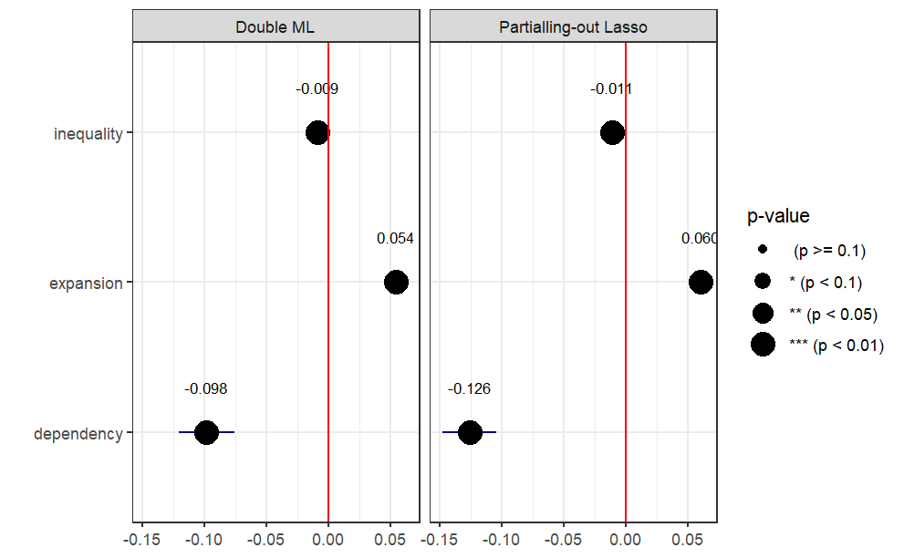

```r
print(Fig_3)
```

The Figure 5 is generated by this code:

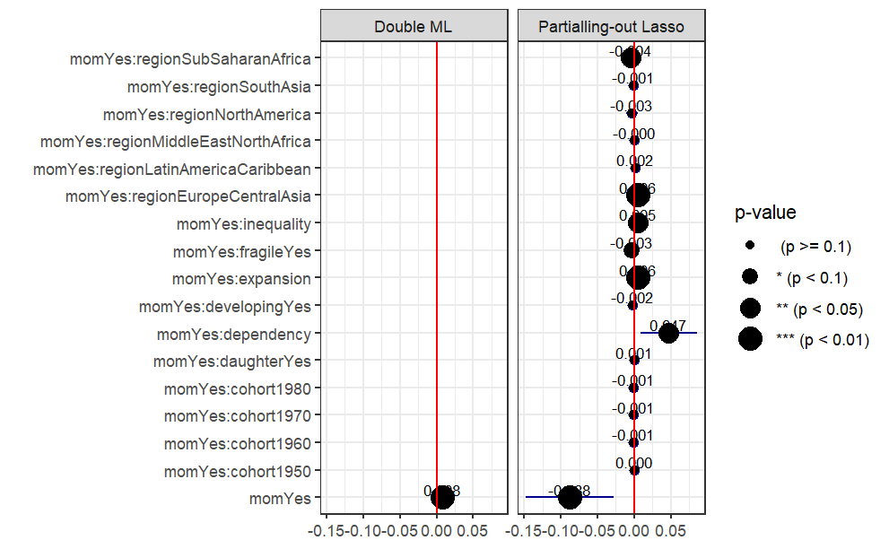

```r
Fig_5 = plot_results(Q2_mom)
print(Fig_5)
```

The Figure 6 is generated by this code:

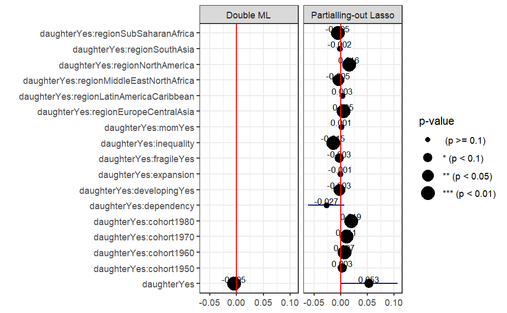

```r
Fig_6 = plot_results(Q2_dau)
print(Fig_6)
```